# Risk Factor Analysis

## Outcome Variable

**Outcome Variable:** ever_stunted

## Predictor Variables

**Intervention Variable:** birthlen

**Adjustment Set:**

- arm
- sex
- W_mage
- meducyrs
- feducyrs
- hhwealth_quart
- vagbrth
- W_nrooms
- brthmon
- W_parity
- impfloor
- impsan
- safeh20
- delta_W_mage
- delta_meducyrs
- delta_feducyrs
- delta_hhwealth_quart
- delta_vagbrth
- delta_W_nrooms
- delta_brthmon
- delta_W_parity
- delta_impfloor
- delta_impsan
- delta_safeh20

## Stratifying Variables

The analysis was stratified on these variable(s):

- agecat
- studyid
- country

## Data Summary

| agecat | studyid | country | birthlen | ever_stunted | n_cell | n |
| --- | --- | --- | --- | --- | --- | --- |
| 0-24 months (no birth st.) | ki0047075b-MAL-ED | BANGLADESH | >=50 cm | 0 | 23 | 211 |
| 0-24 months (no birth st.) | ki0047075b-MAL-ED | BANGLADESH | >=50 cm | 1 | 6 | 211 |
| 0-24 months (no birth st.) | ki0047075b-MAL-ED | BANGLADESH | <48 cm | 0 | 33 | 211 |
| 0-24 months (no birth st.) | ki0047075b-MAL-ED | BANGLADESH | <48 cm | 1 | 64 | 211 |
| 0-24 months (no birth st.) | ki0047075b-MAL-ED | BANGLADESH | [48-50) cm | 0 | 45 | 211 |
| 0-24 months (no birth st.) | ki0047075b-MAL-ED | BANGLADESH | [48-50) cm | 1 | 40 | 211 |
| 0-24 months (no birth st.) | ki0047075b-MAL-ED | BRAZIL | >=50 cm | 0 | 33 | 170 |
| 0-24 months (no birth st.) | ki0047075b-MAL-ED | BRAZIL | >=50 cm | 1 | 1 | 170 |
| 0-24 months (no birth st.) | ki0047075b-MAL-ED | BRAZIL | <48 cm | 0 | 38 | 170 |
| 0-24 months (no birth st.) | ki0047075b-MAL-ED | BRAZIL | <48 cm | 1 | 21 | 170 |
| 0-24 months (no birth st.) | ki0047075b-MAL-ED | BRAZIL | [48-50) cm | 0 | 73 | 170 |
| 0-24 months (no birth st.) | ki0047075b-MAL-ED | BRAZIL | [48-50) cm | 1 | 4 | 170 |
| 0-24 months (no birth st.) | ki0047075b-MAL-ED | INDIA | >=50 cm | 0 | 21 | 174 |
| 0-24 months (no birth st.) | ki0047075b-MAL-ED | INDIA | >=50 cm | 1 | 4 | 174 |
| 0-24 months (no birth st.) | ki0047075b-MAL-ED | INDIA | <48 cm | 0 | 28 | 174 |
| 0-24 months (no birth st.) | ki0047075b-MAL-ED | INDIA | <48 cm | 1 | 47 | 174 |
| 0-24 months (no birth st.) | ki0047075b-MAL-ED | INDIA | [48-50) cm | 0 | 39 | 174 |
| 0-24 months (no birth st.) | ki0047075b-MAL-ED | INDIA | [48-50) cm | 1 | 35 | 174 |
| 0-24 months (no birth st.) | ki0047075b-MAL-ED | NEPAL | >=50 cm | 0 | 37 | 155 |
| 0-24 months (no birth st.) | ki0047075b-MAL-ED | NEPAL | >=50 cm | 1 | 1 | 155 |
| 0-24 months (no birth st.) | ki0047075b-MAL-ED | NEPAL | <48 cm | 0 | 30 | 155 |
| 0-24 months (no birth st.) | ki0047075b-MAL-ED | NEPAL | <48 cm | 1 | 21 | 155 |
| 0-24 months (no birth st.) | ki0047075b-MAL-ED | NEPAL | [48-50) cm | 0 | 48 | 155 |
| 0-24 months (no birth st.) | ki0047075b-MAL-ED | NEPAL | [48-50) cm | 1 | 18 | 155 |
| 0-24 months (no birth st.) | ki0047075b-MAL-ED | PERU | >=50 cm | 0 | 21 | 255 |
| 0-24 months (no birth st.) | ki0047075b-MAL-ED | PERU | >=50 cm | 1 | 13 | 255 |
| 0-24 months (no birth st.) | ki0047075b-MAL-ED | PERU | <48 cm | 0 | 31 | 255 |
| 0-24 months (no birth st.) | ki0047075b-MAL-ED | PERU | <48 cm | 1 | 78 | 255 |
| 0-24 months (no birth st.) | ki0047075b-MAL-ED | PERU | [48-50) cm | 0 | 58 | 255 |
| 0-24 months (no birth st.) | ki0047075b-MAL-ED | PERU | [48-50) cm | 1 | 54 | 255 |

[output cut: 468 more lines]

The following strata were considered:

- agecat: 0-24 months (no birth st.), studyid: ki0047075b-MAL-ED, country: BANGLADESH
- agecat: 0-24 months (no birth st.), studyid: ki0047075b-MAL-ED, country: BRAZIL
- agecat: 0-24 months (no birth st.), studyid: ki0047075b-MAL-ED, country: INDIA
- agecat: 0-24 months (no birth st.), studyid: ki0047075b-MAL-ED, country: NEPAL
- agecat: 0-24 months (no birth st.), studyid: ki0047075b-MAL-ED, country: PERU
- agecat: 0-24 months (no birth st.), studyid: ki0047075b-MAL-ED, country: SOUTH AFRICA
- agecat: 0-24 months (no birth st.), studyid: ki0047075b-MAL-ED, country: TANZANIA, UNITED REPUBLIC OF
- agecat: 0-24 months (no birth st.), studyid: ki1000108-CMC-V-BCS-2002, country: INDIA
- agecat: 0-24 months (no birth st.), studyid: ki1000108-IRC, country: INDIA
- agecat: 0-24 months (no birth st.), studyid: ki1000109-EE, country: PAKISTAN
- agecat: 0-24 months (no birth st.), studyid: ki1000109-ResPak, country: PAKISTAN
- agecat: 0-24 months (no birth st.), studyid: ki1000304b-SAS-CompFeed, country: INDIA
- agecat: 0-24 months (no birth st.), studyid: ki1017093-NIH-Birth, country: BANGLADESH
- agecat: 0-24 months (no birth st.), studyid: ki1017093b-PROVIDE, country: BANGLADESH
- agecat: 0-24 months (no birth st.), studyid: ki1017093c-NIH-Crypto, country: BANGLADESH
- agecat: 0-24 months (no birth st.), studyid: ki1101329-Keneba, country: GAMBIA
- agecat: 0-24 months (no birth st.), studyid: ki1114097-CMIN, country: BANGLADESH
- agecat: 0-24 months (no birth st.), studyid: ki1114097-CMIN, country: BRAZIL
- agecat: 0-24 months (no birth st.), studyid: ki1114097-CMIN, country: GUINEA-BISSAU
- agecat: 0-24 months (no birth st.), studyid: ki1114097-CMIN, country: PERU
- agecat: 0-24 months (no birth st.), studyid: ki1114097-CONTENT, country: PERU
- agecat: 0-24 months (no birth st.), studyid: ki1119695-PROBIT, country: BELARUS
- agecat: 0-24 months (no birth st.), studyid: ki1126311-ZVITAMBO, country: ZIMBABWE
- agecat: 0-24 months (no birth st.), studyid: ki1135781-COHORTS, country: GUATEMALA
- agecat: 0-24 months (no birth st.), studyid: ki1135781-COHORTS, country: INDIA
- agecat: 0-24 months (no birth st.), studyid: ki1135781-COHORTS, country: PHILIPPINES
- agecat: 0-24 months (no birth st.), studyid: kiGH5241-JiVitA-3, country: BANGLADESH
- agecat: 0-24 months (no birth st.), studyid: kiGH5241-JiVitA-4, country: BANGLADESH
- agecat: 0-6 months (no birth st.), studyid: ki0047075b-MAL-ED, country: BANGLADESH
- agecat: 0-6 months (no birth st.), studyid: ki0047075b-MAL-ED, country: BRAZIL
- agecat: 0-6 months (no birth st.), studyid: ki0047075b-MAL-ED, country: INDIA
- agecat: 0-6 months (no birth st.), studyid: ki0047075b-MAL-ED, country: NEPAL
- agecat: 0-6 months (no birth st.), studyid: ki0047075b-MAL-ED, country: PERU
- agecat: 0-6 months (no birth st.), studyid: ki0047075b-MAL-ED, country: SOUTH AFRICA
- agecat: 0-6 months (no birth st.), studyid: ki0047075b-MAL-ED, country: TANZANIA, UNITED REPUBLIC OF
- agecat: 0-6 months (no birth st.), studyid: ki1000108-CMC-V-BCS-2002, country: INDIA
- agecat: 0-6 months (no birth st.), studyid: ki1000108-IRC, country: INDIA
- agecat: 0-6 months (no birth st.), studyid: ki1000109-EE, country: PAKISTAN
- agecat: 0-6 months (no birth st.), studyid: ki1000109-ResPak, country: PAKISTAN
- agecat: 0-6 months (no birth st.), studyid: ki1000304b-SAS-CompFeed, country: INDIA
- agecat: 0-6 months (no birth st.), studyid: ki1017093-NIH-Birth, country: BANGLADESH
- agecat: 0-6 months (no birth st.), studyid: ki1017093b-PROVIDE, country: BANGLADESH
- agecat: 0-6 months (no birth st.), studyid: ki1017093c-NIH-Crypto, country: BANGLADESH
- agecat: 0-6 months (no birth st.), studyid: ki1101329-Keneba, country: GAMBIA
- agecat: 0-6 months (no birth st.), studyid: ki1114097-CMIN, country: BANGLADESH
- agecat: 0-6 months (no birth st.), studyid: ki1114097-CMIN, country: BRAZIL
- agecat: 0-6 months (no birth st.), studyid: ki1114097-CMIN, country: GUINEA-BISSAU
- agecat: 0-6 months (no birth st.), studyid: ki1114097-CMIN, country: PERU
- agecat: 0-6 months (no birth st.), studyid: ki1114097-CONTENT, country: PERU
- agecat: 0-6 months (no birth st.), studyid: ki1119695-PROBIT, country: BELARUS
- agecat: 0-6 months (no birth st.), studyid: ki1126311-ZVITAMBO, country: ZIMBABWE
- agecat: 0-6 months (no birth st.), studyid: ki1135781-COHORTS, country: GUATEMALA
- agecat: 0-6 months (no birth st.), studyid: ki1135781-COHORTS, country: INDIA
- agecat: 0-6 months (no birth st.), studyid: ki1135781-COHORTS, country: PHILIPPINES
- agecat: 0-6 months (no birth st.), studyid: kiGH5241-JiVitA-3, country: BANGLADESH
- agecat: 0-6 months (no birth st.), studyid: kiGH5241-JiVitA-4, country: BANGLADESH
- agecat: 6-24 months, studyid: ki0047075b-MAL-ED, country: BANGLADESH
- agecat: 6-24 months, studyid: ki0047075b-MAL-ED, country: BRAZIL
- agecat: 6-24 months, studyid: ki0047075b-MAL-ED, country: INDIA
- agecat: 6-24 months, studyid: ki0047075b-MAL-ED, country: NEPAL
- agecat: 6-24 months, studyid: ki0047075b-MAL-ED, country: PERU
- agecat: 6-24 months, studyid: ki0047075b-MAL-ED, country: SOUTH AFRICA
- agecat: 6-24 months, studyid: ki0047075b-MAL-ED, country: TANZANIA, UNITED REPUBLIC OF
- agecat: 6-24 months, studyid: ki1000108-CMC-V-BCS-2002, country: INDIA
- agecat: 6-24 months, studyid: ki1000108-IRC, country: INDIA
- agecat: 6-24 months, studyid: ki1000109-EE, country: PAKISTAN
- agecat: 6-24 months, studyid: ki1000109-ResPak, country: PAKISTAN
- agecat: 6-24 months, studyid: ki1000304b-SAS-CompFeed, country: INDIA
- agecat: 6-24 months, studyid: ki1017093-NIH-Birth, country: BANGLADESH
- agecat: 6-24 months, studyid: ki1017093b-PROVIDE, country: BANGLADESH
- agecat: 6-24 months, studyid: ki1017093c-NIH-Crypto, country: BANGLADESH
- agecat: 6-24 months, studyid: ki1101329-Keneba, country: GAMBIA
- agecat: 6-24 months, studyid: ki1114097-CMIN, country: BRAZIL
- agecat: 6-24 months, studyid: ki1114097-CMIN, country: GUINEA-BISSAU
- agecat: 6-24 months, studyid: ki1114097-CMIN, country: PERU
- agecat: 6-24 months, studyid: ki1114097-CONTENT, country: PERU
- agecat: 6-24 months, studyid: ki1119695-PROBIT, country: BELARUS
- agecat: 6-24 months, studyid: ki1126311-ZVITAMBO, country: ZIMBABWE
- agecat: 6-24 months, studyid: ki1135781-COHORTS, country: GUATEMALA
- agecat: 6-24 months, studyid: ki1135781-COHORTS, country: INDIA
- agecat: 6-24 months, studyid: ki1135781-COHORTS, country: PHILIPPINES
- agecat: 6-24 months, studyid: kiGH5241-JiVitA-3, country: BANGLADESH
- agecat: 6-24 months, studyid: kiGH5241-JiVitA-4, country: BANGLADESH

### Dropped Strata

Some strata were dropped due to rare outcomes:

- agecat: 0-24 months (no birth st.), studyid: ki0047075b-MAL-ED, country: BRAZIL
- agecat: 0-24 months (no birth st.), studyid: ki0047075b-MAL-ED, country: INDIA
- agecat: 0-24 months (no birth st.), studyid: ki0047075b-MAL-ED, country: NEPAL
- agecat: 0-24 months (no birth st.), studyid: ki1000108-CMC-V-BCS-2002, country: INDIA
- agecat: 0-24 months (no birth st.), studyid: ki1000109-EE, country: PAKISTAN
- agecat: 0-24 months (no birth st.), studyid: ki1000109-ResPak, country: PAKISTAN
- agecat: 0-24 months (no birth st.), studyid: ki1114097-CMIN, country: BANGLADESH
- agecat: 0-24 months (no birth st.), studyid: ki1114097-CMIN, country: GUINEA-BISSAU
- agecat: 0-24 months (no birth st.), studyid: ki1114097-CMIN, country: PERU
- agecat: 0-24 months (no birth st.), studyid: ki1114097-CONTENT, country: PERU
- agecat: 0-6 months (no birth st.), studyid: ki0047075b-MAL-ED, country: BANGLADESH
- agecat: 0-6 months (no birth st.), studyid: ki0047075b-MAL-ED, country: BRAZIL
- agecat: 0-6 months (no birth st.), studyid: ki0047075b-MAL-ED, country: INDIA
- agecat: 0-6 months (no birth st.), studyid: ki0047075b-MAL-ED, country: NEPAL
- agecat: 0-6 months (no birth st.), studyid: ki0047075b-MAL-ED, country: PERU
- agecat: 0-6 months (no birth st.), studyid: ki0047075b-MAL-ED, country: TANZANIA, UNITED REPUBLIC OF
- agecat: 0-6 months (no birth st.), studyid: ki1000109-ResPak, country: PAKISTAN
- agecat: 0-6 months (no birth st.), studyid: ki1017093-NIH-Birth, country: BANGLADESH
- agecat: 0-6 months (no birth st.), studyid: ki1017093b-PROVIDE, country: BANGLADESH
- agecat: 0-6 months (no birth st.), studyid: ki1017093c-NIH-Crypto, country: BANGLADESH
- agecat: 0-6 months (no birth st.), studyid: ki1114097-CMIN, country: BANGLADESH
- agecat: 0-6 months (no birth st.), studyid: ki1114097-CMIN, country: BRAZIL
- agecat: 0-6 months (no birth st.), studyid: ki1114097-CMIN, country: GUINEA-BISSAU
- agecat: 0-6 months (no birth st.), studyid: ki1114097-CMIN, country: PERU
- agecat: 0-6 months (no birth st.), studyid: ki1114097-CONTENT, country: PERU
- agecat: 6-24 months, studyid: ki0047075b-MAL-ED, country: BRAZIL
- agecat: 6-24 months, studyid: ki0047075b-MAL-ED, country: INDIA
- agecat: 6-24 months, studyid: ki0047075b-MAL-ED, country: NEPAL
- agecat: 6-24 months, studyid: ki0047075b-MAL-ED, country: TANZANIA, UNITED REPUBLIC OF
- agecat: 6-24 months, studyid: ki1000108-CMC-V-BCS-2002, country: INDIA
- agecat: 6-24 months, studyid: ki1000109-EE, country: PAKISTAN
- agecat: 6-24 months, studyid: ki1000109-ResPak, country: PAKISTAN
- agecat: 6-24 months, studyid: ki1114097-CMIN, country: BRAZIL
- agecat: 6-24 months, studyid: ki1114097-CMIN, country: GUINEA-BISSAU
- agecat: 6-24 months, studyid: ki1114097-CMIN, country: PERU
- agecat: 6-24 months, studyid: ki1114097-CONTENT, country: PERU

## Methods Detail

We’re interested in the causal parameters $E[Y_a]$ for all values of $a \in \mathcal{A}$. These parameters represent the mean outcome if, possibly contrary to fact, we intervened to set all units to have $A=a$. Under the randomization and positivity assumptions, these are identified by the statistical parameters $\psi_a=E_W[E_{Y|A,W}(Y|A=a,W)]$. In addition, we’re interested in the mean of $Y$, $E[Y]$ under no intervention (the observed mean). We will estimate these parameters by using SuperLearner to fit the relevant likelihood factors – $E_{Y|A,W}(Y|A=a,W)$ and $p(A=a|W)$, and then updating our likelihood fit using a joint TMLE.

For unadjusted analyses ($W=\{\}$), initial likelihoods were estimated using Lrnr_glm to estimate the simple $E(Y|A)$ and Lrnr_mean to estimate $p(A)$. For adjusted analyses, a small library containing Lrnr_glmnet, Lrnr_xgboost, and Lrnr_mean was used.

Having estimated these parameters, we will then use the delta method to estimate relative risks and attributable risks relative to a prespecified baseline level of $A$.

# Results Detail

## Results Plots

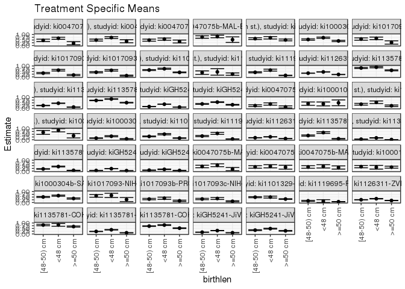

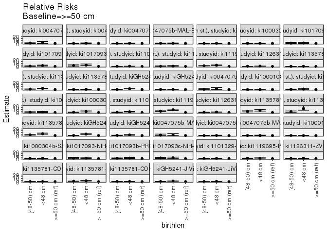

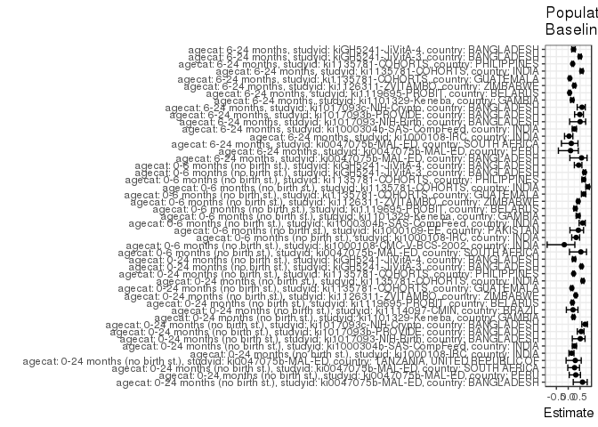

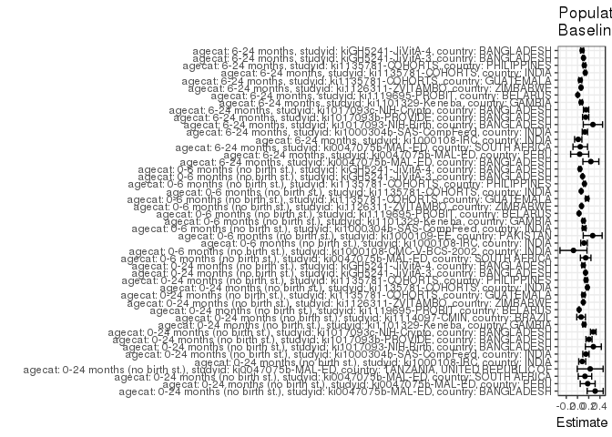

## Results Table

### Parameter: TSM

| agecat | studyid | country | intervention_level | baseline_level | estimate | ci_lower | ci_upper |
| --- | --- | --- | --- | --- | --- | --- | --- |
| 0-24 months (no birth st.) | ki0047075b-MAL-ED | BANGLADESH | >=50 cm | NA | 0.2068966 | 0.0591143 | 0.3546788 |
| 0-24 months (no birth st.) | ki0047075b-MAL-ED | BANGLADESH | <48 cm | NA | 0.6597938 | 0.5652857 | 0.7543019 |
| 0-24 months (no birth st.) | ki0047075b-MAL-ED | BANGLADESH | [48-50) cm | NA | 0.4705882 | 0.3642260 | 0.5769505 |
| 0-24 months (no birth st.) | ki0047075b-MAL-ED | PERU | >=50 cm | NA | 0.3873960 | 0.2463593 | 0.5284328 |
| 0-24 months (no birth st.) | ki0047075b-MAL-ED | PERU | <48 cm | NA | 0.7208603 | 0.6381975 | 0.8035231 |
| 0-24 months (no birth st.) | ki0047075b-MAL-ED | PERU | [48-50) cm | NA | 0.4939356 | 0.4040937 | 0.5837775 |
| 0-24 months (no birth st.) | ki0047075b-MAL-ED | SOUTH AFRICA | >=50 cm | NA | 0.3628255 | 0.2302200 | 0.4954310 |
| 0-24 months (no birth st.) | ki0047075b-MAL-ED | SOUTH AFRICA | <48 cm | NA | 0.5799589 | 0.4782450 | 0.6816727 |
| 0-24 months (no birth st.) | ki0047075b-MAL-ED | SOUTH AFRICA | [48-50) cm | NA | 0.4872428 | 0.3920825 | 0.5824032 |
| 0-24 months (no birth st.) | ki0047075b-MAL-ED | TANZANIA, UNITED REPUBLIC OF | >=50 cm | NA | 0.5333333 | 0.2796890 | 0.7869777 |
| 0-24 months (no birth st.) | ki0047075b-MAL-ED | TANZANIA, UNITED REPUBLIC OF | <48 cm | NA | 0.8250000 | 0.7067002 | 0.9432998 |
| 0-24 months (no birth st.) | ki0047075b-MAL-ED | TANZANIA, UNITED REPUBLIC OF | [48-50) cm | NA | 0.7735849 | 0.6603874 | 0.8867824 |
| 0-24 months (no birth st.) | ki1000108-IRC | INDIA | >=50 cm | NA | 0.5071715 | 0.4251879 | 0.5891551 |
| 0-24 months (no birth st.) | ki1000108-IRC | INDIA | <48 cm | NA | 0.7035302 | 0.5940782 | 0.8129823 |
| 0-24 months (no birth st.) | ki1000108-IRC | INDIA | [48-50) cm | NA | 0.6251290 | 0.5443850 | 0.7058730 |
| 0-24 months (no birth st.) | ki1000304b-SAS-CompFeed | INDIA | >=50 cm | NA | 0.4157957 | 0.3594608 | 0.4721305 |
| 0-24 months (no birth st.) | ki1000304b-SAS-CompFeed | INDIA | <48 cm | NA | 0.7119015 | 0.6541927 | 0.7696103 |
| 0-24 months (no birth st.) | ki1000304b-SAS-CompFeed | INDIA | [48-50) cm | NA | 0.5460237 | 0.4844323 | 0.6076152 |
| 0-24 months (no birth st.) | ki1017093-NIH-Birth | BANGLADESH | >=50 cm | NA | 0.2727273 | 0.1203569 | 0.4250976 |
| 0-24 months (no birth st.) | ki1017093-NIH-Birth | BANGLADESH | <48 cm | NA | 0.6515152 | 0.5362424 | 0.7667879 |
| 0-24 months (no birth st.) | ki1017093-NIH-Birth | BANGLADESH | [48-50) cm | NA | 0.5903614 | 0.4842738 | 0.6964491 |
| 0-24 months (no birth st.) | ki1017093b-PROVIDE | BANGLADESH | >=50 cm | NA | 0.1707891 | 0.1138367 | 0.2277415 |
| 0-24 months (no birth st.) | ki1017093b-PROVIDE | BANGLADESH | <48 cm | NA | 0.6121759 | 0.5413936 | 0.6829582 |
| 0-24 months (no birth st.) | ki1017093b-PROVIDE | BANGLADESH | [48-50) cm | NA | 0.3456910 | 0.2902574 | 0.4011245 |
| 0-24 months (no birth st.) | ki1017093c-NIH-Crypto | BANGLADESH | >=50 cm | NA | 0.1126848 | 0.0649194 | 0.1604501 |
| 0-24 months (no birth st.) | ki1017093c-NIH-Crypto | BANGLADESH | <48 cm | NA | 0.5991446 | 0.5288063 | 0.6694830 |
| 0-24 months (no birth st.) | ki1017093c-NIH-Crypto | BANGLADESH | [48-50) cm | NA | 0.4232042 | 0.3671283 | 0.4792802 |
| 0-24 months (no birth st.) | ki1101329-Keneba | GAMBIA | >=50 cm | NA | 0.4120077 | 0.3780408 | 0.4459746 |
| 0-24 months (no birth st.) | ki1101329-Keneba | GAMBIA | <48 cm | NA | 0.7408887 | 0.6874523 | 0.7943251 |
| 0-24 months (no birth st.) | ki1101329-Keneba | GAMBIA | [48-50) cm | NA | 0.6248389 | 0.5846306 | 0.6650471 |

[output cut: 111 more lines]

### Parameter: E(Y)

| agecat | studyid | country | intervention_level | baseline_level | estimate | ci_lower | ci_upper |
| --- | --- | --- | --- | --- | --- | --- | --- |
| 0-24 months (no birth st.) | ki0047075b-MAL-ED | BANGLADESH | NA | NA | 0.5213270 | 0.4537634 | 0.5888907 |
| 0-24 months (no birth st.) | ki0047075b-MAL-ED | PERU | NA | NA | 0.5686275 | 0.5077199 | 0.6295350 |
| 0-24 months (no birth st.) | ki0047075b-MAL-ED | SOUTH AFRICA | NA | NA | 0.4957265 | 0.4315281 | 0.5599249 |
| 0-24 months (no birth st.) | ki0047075b-MAL-ED | TANZANIA, UNITED REPUBLIC OF | NA | NA | 0.7592593 | 0.6782516 | 0.8402669 |
| 0-24 months (no birth st.) | ki1000108-IRC | INDIA | NA | NA | 0.5913043 | 0.5393557 | 0.6432530 |
| 0-24 months (no birth st.) | ki1000304b-SAS-CompFeed | INDIA | NA | NA | 0.5657407 | 0.5074689 | 0.6240126 |
| 0-24 months (no birth st.) | ki1017093-NIH-Birth | BANGLADESH | NA | NA | 0.5549451 | 0.4825447 | 0.6273454 |
| 0-24 months (no birth st.) | ki1017093b-PROVIDE | BANGLADESH | NA | NA | 0.3753943 | 0.3376725 | 0.4131162 |
| 0-24 months (no birth st.) | ki1017093c-NIH-Crypto | BANGLADESH | NA | NA | 0.3935681 | 0.3560687 | 0.4310676 |
| 0-24 months (no birth st.) | ki1101329-Keneba | GAMBIA | NA | NA | 0.5296120 | 0.5040796 | 0.5551444 |
| 0-24 months (no birth st.) | ki1114097-CMIN | BRAZIL | NA | NA | 0.3181818 | 0.2307425 | 0.4056211 |
| 0-24 months (no birth st.) | ki1119695-PROBIT | BELARUS | NA | NA | 0.1597778 | 0.1408215 | 0.1787342 |
| 0-24 months (no birth st.) | ki1126311-ZVITAMBO | ZIMBABWE | NA | NA | 0.3260417 | 0.3178171 | 0.3342662 |
| 0-24 months (no birth st.) | ki1135781-COHORTS | GUATEMALA | NA | NA | 0.7082294 | 0.6767491 | 0.7397098 |
| 0-24 months (no birth st.) | ki1135781-COHORTS | INDIA | NA | NA | 0.2867647 | 0.2751726 | 0.2983568 |
| 0-24 months (no birth st.) | ki1135781-COHORTS | PHILIPPINES | NA | NA | 0.6671324 | 0.6498678 | 0.6843969 |
| 0-24 months (no birth st.) | kiGH5241-JiVitA-3 | BANGLADESH | NA | NA | 0.2544754 | 0.2466027 | 0.2623480 |
| 0-24 months (no birth st.) | kiGH5241-JiVitA-4 | BANGLADESH | NA | NA | 0.4273585 | 0.4069266 | 0.4477904 |
| 0-6 months (no birth st.) | ki0047075b-MAL-ED | SOUTH AFRICA | NA | NA | 0.2735043 | 0.2162683 | 0.3307402 |
| 0-6 months (no birth st.) | ki1000108-CMC-V-BCS-2002 | INDIA | NA | NA | 0.4285714 | 0.3221077 | 0.5350351 |
| 0-6 months (no birth st.) | ki1000108-IRC | INDIA | NA | NA | 0.3478261 | 0.2974955 | 0.3981566 |
| 0-6 months (no birth st.) | ki1000109-EE | PAKISTAN | NA | NA | 0.6338028 | 0.5209445 | 0.7466612 |
| 0-6 months (no birth st.) | ki1000304b-SAS-CompFeed | INDIA | NA | NA | 0.1946247 | 0.1703263 | 0.2189230 |
| 0-6 months (no birth st.) | ki1101329-Keneba | GAMBIA | NA | NA | 0.2552757 | 0.2329715 | 0.2775799 |
| 0-6 months (no birth st.) | ki1119695-PROBIT | BELARUS | NA | NA | 0.0912784 | 0.0781588 | 0.1043979 |
| 0-6 months (no birth st.) | ki1126311-ZVITAMBO | ZIMBABWE | NA | NA | 0.1716896 | 0.1650721 | 0.1783072 |
| 0-6 months (no birth st.) | ki1135781-COHORTS | GUATEMALA | NA | NA | 0.2581047 | 0.2278007 | 0.2884088 |
| 0-6 months (no birth st.) | ki1135781-COHORTS | INDIA | NA | NA | 0.0790014 | 0.0720874 | 0.0859154 |
| 0-6 months (no birth st.) | ki1135781-COHORTS | PHILIPPINES | NA | NA | 0.1893119 | 0.1749594 | 0.2036645 |
| 0-6 months (no birth st.) | kiGH5241-JiVitA-3 | BANGLADESH | NA | NA | 0.1321472 | 0.1264309 | 0.1378635 |
| 0-6 months (no birth st.) | kiGH5241-JiVitA-4 | BANGLADESH | NA | NA | 0.0984277 | 0.0855770 | 0.1112784 |
| 6-24 months | ki0047075b-MAL-ED | BANGLADESH | NA | NA | 0.4230769 | 0.3453000 | 0.5008539 |
| 6-24 months | ki0047075b-MAL-ED | PERU | NA | NA | 0.3958333 | 0.3156813 | 0.4759854 |
| 6-24 months | ki0047075b-MAL-ED | SOUTH AFRICA | NA | NA | 0.3795620 | 0.2980035 | 0.4611205 |
| 6-24 months | ki1000108-IRC | INDIA | NA | NA | 0.3733333 | 0.3099915 | 0.4366752 |
| 6-24 months | ki1000304b-SAS-CompFeed | INDIA | NA | NA | 0.5006242 | 0.4555100 | 0.5457384 |
| 6-24 months | ki1017093-NIH-Birth | BANGLADESH | NA | NA | 0.5471698 | 0.4519599 | 0.6423797 |
| 6-24 months | ki1017093b-PROVIDE | BANGLADESH | NA | NA | 0.2997812 | 0.2577294 | 0.3418330 |
| 6-24 months | ki1017093c-NIH-Crypto | BANGLADESH | NA | NA | 0.2628458 | 0.2244546 | 0.3012371 |
| 6-24 months | ki1101329-Keneba | GAMBIA | NA | NA | 0.3816288 | 0.3523153 | 0.4109422 |
| 6-24 months | ki1119695-PROBIT | BELARUS | NA | NA | 0.0768510 | 0.0628857 | 0.0908164 |
| 6-24 months | ki1126311-ZVITAMBO | ZIMBABWE | NA | NA | 0.2452926 | 0.2357801 | 0.2548051 |
| 6-24 months | ki1135781-COHORTS | GUATEMALA | NA | NA | 0.7234469 | 0.6841620 | 0.7627318 |
| 6-24 months | ki1135781-COHORTS | INDIA | NA | NA | 0.2424242 | 0.2305635 | 0.2542850 |
| 6-24 months | ki1135781-COHORTS | PHILIPPINES | NA | NA | 0.6465028 | 0.6261291 | 0.6668766 |
| 6-24 months | kiGH5241-JiVitA-3 | BANGLADESH | NA | NA | 0.2160458 | 0.2066156 | 0.2254760 |
| 6-24 months | kiGH5241-JiVitA-4 | BANGLADESH | NA | NA | 0.3663989 | 0.3454886 | 0.3873091 |

### Parameter: RR

| agecat | studyid | country | intervention_level | baseline_level | estimate | ci_lower | ci_upper |
| --- | --- | --- | --- | --- | --- | --- | --- |
| 0-24 months (no birth st.) | ki0047075b-MAL-ED | BANGLADESH | >=50 cm | >=50 cm | 1.0000000 | 1.0000000 | 1.000000 |
| 0-24 months (no birth st.) | ki0047075b-MAL-ED | BANGLADESH | <48 cm | >=50 cm | 3.1890034 | 1.5391141 | 6.607530 |
| 0-24 months (no birth st.) | ki0047075b-MAL-ED | BANGLADESH | [48-50) cm | >=50 cm | 2.2745098 | 1.0752756 | 4.811227 |
| 0-24 months (no birth st.) | ki0047075b-MAL-ED | PERU | >=50 cm | >=50 cm | 1.0000000 | 1.0000000 | 1.000000 |
| 0-24 months (no birth st.) | ki0047075b-MAL-ED | PERU | <48 cm | >=50 cm | 1.8607839 | 1.2707789 | 2.724720 |
| 0-24 months (no birth st.) | ki0047075b-MAL-ED | PERU | [48-50) cm | >=50 cm | 1.2750146 | 0.8496200 | 1.913399 |
| 0-24 months (no birth st.) | ki0047075b-MAL-ED | SOUTH AFRICA | >=50 cm | >=50 cm | 1.0000000 | 1.0000000 | 1.000000 |
| 0-24 months (no birth st.) | ki0047075b-MAL-ED | SOUTH AFRICA | <48 cm | >=50 cm | 1.5984513 | 1.0661315 | 2.396558 |
| 0-24 months (no birth st.) | ki0047075b-MAL-ED | SOUTH AFRICA | [48-50) cm | >=50 cm | 1.3429124 | 0.8869227 | 2.033338 |
| 0-24 months (no birth st.) | ki0047075b-MAL-ED | TANZANIA, UNITED REPUBLIC OF | >=50 cm | >=50 cm | 1.0000000 | 1.0000000 | 1.000000 |
| 0-24 months (no birth st.) | ki0047075b-MAL-ED | TANZANIA, UNITED REPUBLIC OF | <48 cm | >=50 cm | 1.5468750 | 0.9412997 | 2.542041 |
| 0-24 months (no birth st.) | ki0047075b-MAL-ED | TANZANIA, UNITED REPUBLIC OF | [48-50) cm | >=50 cm | 1.4504717 | 0.8818823 | 2.385657 |
| 0-24 months (no birth st.) | ki1000108-IRC | INDIA | >=50 cm | >=50 cm | 1.0000000 | 1.0000000 | 1.000000 |
| 0-24 months (no birth st.) | ki1000108-IRC | INDIA | <48 cm | >=50 cm | 1.3871644 | 1.1092387 | 1.734726 |
| 0-24 months (no birth st.) | ki1000108-IRC | INDIA | [48-50) cm | >=50 cm | 1.2325792 | 1.0026589 | 1.515223 |
| 0-24 months (no birth st.) | ki1000304b-SAS-CompFeed | INDIA | >=50 cm | >=50 cm | 1.0000000 | 1.0000000 | 1.000000 |
| 0-24 months (no birth st.) | ki1000304b-SAS-CompFeed | INDIA | <48 cm | >=50 cm | 1.7121427 | 1.4752016 | 1.987140 |
| 0-24 months (no birth st.) | ki1000304b-SAS-CompFeed | INDIA | [48-50) cm | >=50 cm | 1.3132020 | 1.1630231 | 1.482773 |
| 0-24 months (no birth st.) | ki1017093-NIH-Birth | BANGLADESH | >=50 cm | >=50 cm | 1.0000000 | 1.0000000 | 1.000000 |
| 0-24 months (no birth st.) | ki1017093-NIH-Birth | BANGLADESH | <48 cm | >=50 cm | 2.3888889 | 1.3294836 | 4.292486 |
| 0-24 months (no birth st.) | ki1017093-NIH-Birth | BANGLADESH | [48-50) cm | >=50 cm | 2.1646586 | 1.2036793 | 3.892854 |
| 0-24 months (no birth st.) | ki1017093b-PROVIDE | BANGLADESH | >=50 cm | >=50 cm | 1.0000000 | 1.0000000 | 1.000000 |
| 0-24 months (no birth st.) | ki1017093b-PROVIDE | BANGLADESH | <48 cm | >=50 cm | 3.5843965 | 2.5184809 | 5.101447 |
| 0-24 months (no birth st.) | ki1017093b-PROVIDE | BANGLADESH | [48-50) cm | >=50 cm | 2.0240807 | 1.3980223 | 2.930499 |
| 0-24 months (no birth st.) | ki1017093c-NIH-Crypto | BANGLADESH | >=50 cm | >=50 cm | 1.0000000 | 1.0000000 | 1.000000 |
| 0-24 months (no birth st.) | ki1017093c-NIH-Crypto | BANGLADESH | <48 cm | >=50 cm | 5.3169973 | 3.4254943 | 8.252958 |
| 0-24 months (no birth st.) | ki1017093c-NIH-Crypto | BANGLADESH | [48-50) cm | >=50 cm | 3.7556467 | 2.4096677 | 5.853455 |
| 0-24 months (no birth st.) | ki1101329-Keneba | GAMBIA | >=50 cm | >=50 cm | 1.0000000 | 1.0000000 | 1.000000 |
| 0-24 months (no birth st.) | ki1101329-Keneba | GAMBIA | <48 cm | >=50 cm | 1.7982399 | 1.6125183 | 2.005352 |
| 0-24 months (no birth st.) | ki1101329-Keneba | GAMBIA | [48-50) cm | >=50 cm | 1.5165709 | 1.3675318 | 1.681853 |

[output cut: 111 more lines]

### Parameter: PAR

| agecat | studyid | country | intervention_level | baseline_level | estimate | ci_lower | ci_upper |
| --- | --- | --- | --- | --- | --- | --- | --- |
| 0-24 months (no birth st.) | ki0047075b-MAL-ED | BANGLADESH | >=50 cm | NA | 0.3144305 | 0.1715979 | 0.4572630 |
| 0-24 months (no birth st.) | ki0047075b-MAL-ED | PERU | >=50 cm | NA | 0.1812314 | 0.0486191 | 0.3138437 |
| 0-24 months (no birth st.) | ki0047075b-MAL-ED | SOUTH AFRICA | >=50 cm | NA | 0.1329010 | 0.0130606 | 0.2527414 |
| 0-24 months (no birth st.) | ki0047075b-MAL-ED | TANZANIA, UNITED REPUBLIC OF | >=50 cm | NA | 0.2259259 | -0.0043494 | 0.4562013 |
| 0-24 months (no birth st.) | ki1000108-IRC | INDIA | >=50 cm | NA | 0.0841329 | 0.0221821 | 0.1460836 |
| 0-24 months (no birth st.) | ki1000304b-SAS-CompFeed | INDIA | >=50 cm | NA | 0.1499451 | 0.0939042 | 0.2059860 |
| 0-24 months (no birth st.) | ki1017093-NIH-Birth | BANGLADESH | >=50 cm | NA | 0.2822178 | 0.1406576 | 0.4237780 |
| 0-24 months (no birth st.) | ki1017093b-PROVIDE | BANGLADESH | >=50 cm | NA | 0.2046052 | 0.1504034 | 0.2588070 |
| 0-24 months (no birth st.) | ki1017093c-NIH-Crypto | BANGLADESH | >=50 cm | NA | 0.2808834 | 0.2307971 | 0.3309696 |
| 0-24 months (no birth st.) | ki1101329-Keneba | GAMBIA | >=50 cm | NA | 0.1176043 | 0.0938948 | 0.1413138 |
| 0-24 months (no birth st.) | ki1114097-CMIN | BRAZIL | >=50 cm | NA | 0.0642136 | -0.0129213 | 0.1413485 |
| 0-24 months (no birth st.) | ki1119695-PROBIT | BELARUS | >=50 cm | NA | 0.0283733 | 0.0220774 | 0.0346693 |
| 0-24 months (no birth st.) | ki1126311-ZVITAMBO | ZIMBABWE | >=50 cm | NA | 0.1035742 | 0.0927368 | 0.1144117 |
| 0-24 months (no birth st.) | ki1135781-COHORTS | GUATEMALA | >=50 cm | NA | 0.1072135 | 0.0790628 | 0.1353642 |
| 0-24 months (no birth st.) | ki1135781-COHORTS | INDIA | >=50 cm | NA | 0.1760793 | 0.1604813 | 0.1916772 |
| 0-24 months (no birth st.) | ki1135781-COHORTS | PHILIPPINES | >=50 cm | NA | 0.1521502 | 0.1311766 | 0.1731239 |
| 0-24 months (no birth st.) | kiGH5241-JiVitA-3 | BANGLADESH | >=50 cm | NA | 0.1428688 | 0.1322818 | 0.1534558 |
| 0-24 months (no birth st.) | kiGH5241-JiVitA-4 | BANGLADESH | >=50 cm | NA | 0.1044182 | 0.0765460 | 0.1322904 |
| 0-6 months (no birth st.) | ki0047075b-MAL-ED | SOUTH AFRICA | >=50 cm | NA | 0.1458447 | 0.0523301 | 0.2393593 |
| 0-6 months (no birth st.) | ki1000108-CMC-V-BCS-2002 | INDIA | >=50 cm | NA | -0.0714286 | -0.3114643 | 0.1686072 |
| 0-6 months (no birth st.) | ki1000108-IRC | INDIA | >=50 cm | NA | 0.1163146 | 0.0582712 | 0.1743579 |
| 0-6 months (no birth st.) | ki1000109-EE | PAKISTAN | >=50 cm | NA | 0.2701665 | 0.1018745 | 0.4384584 |
| 0-6 months (no birth st.) | ki1000304b-SAS-CompFeed | INDIA | >=50 cm | NA | 0.1185999 | 0.0858644 | 0.1513354 |
| 0-6 months (no birth st.) | ki1101329-Keneba | GAMBIA | >=50 cm | NA | 0.1069049 | 0.0855658 | 0.1282440 |
| 0-6 months (no birth st.) | ki1119695-PROBIT | BELARUS | >=50 cm | NA | 0.0273682 | 0.0216867 | 0.0330496 |
| 0-6 months (no birth st.) | ki1126311-ZVITAMBO | ZIMBABWE | >=50 cm | NA | 0.0723165 | 0.0639353 | 0.0806977 |
| 0-6 months (no birth st.) | ki1135781-COHORTS | GUATEMALA | >=50 cm | NA | 0.1703342 | 0.1414807 | 0.1991877 |
| 0-6 months (no birth st.) | ki1135781-COHORTS | INDIA | >=50 cm | NA | 0.0657792 | 0.0576827 | 0.0738757 |
| 0-6 months (no birth st.) | ki1135781-COHORTS | PHILIPPINES | >=50 cm | NA | 0.1238910 | 0.1082680 | 0.1395139 |
| 0-6 months (no birth st.) | kiGH5241-JiVitA-3 | BANGLADESH | >=50 cm | NA | 0.0907649 | 0.0834038 | 0.0981259 |
| 0-6 months (no birth st.) | kiGH5241-JiVitA-4 | BANGLADESH | >=50 cm | NA | 0.0432553 | 0.0272346 | 0.0592759 |
| 6-24 months | ki0047075b-MAL-ED | BANGLADESH | >=50 cm | NA | 0.2378917 | 0.0958468 | 0.3799367 |
| 6-24 months | ki0047075b-MAL-ED | PERU | >=50 cm | NA | 0.0386905 | -0.1219590 | 0.1993400 |
| 6-24 months | ki0047075b-MAL-ED | SOUTH AFRICA | >=50 cm | NA | 0.0490303 | -0.0802752 | 0.1783357 |
| 6-24 months | ki1000108-IRC | INDIA | >=50 cm | NA | 0.0132333 | -0.0518152 | 0.0782817 |
| 6-24 months | ki1000304b-SAS-CompFeed | INDIA | >=50 cm | NA | 0.1313939 | 0.0839326 | 0.1788551 |
| 6-24 months | ki1017093-NIH-Birth | BANGLADESH | >=50 cm | NA | 0.2744425 | 0.1026423 | 0.4462428 |
| 6-24 months | ki1017093b-PROVIDE | BANGLADESH | >=50 cm | NA | 0.1456684 | 0.0899380 | 0.2013989 |
| 6-24 months | ki1017093c-NIH-Crypto | BANGLADESH | >=50 cm | NA | 0.1529218 | 0.1054022 | 0.2004414 |
| 6-24 months | ki1101329-Keneba | GAMBIA | >=50 cm | NA | 0.0637601 | 0.0399870 | 0.0875331 |
| 6-24 months | ki1119695-PROBIT | BELARUS | >=50 cm | NA | 0.0045550 | 0.0017845 | 0.0073256 |
| 6-24 months | ki1126311-ZVITAMBO | ZIMBABWE | >=50 cm | NA | 0.0631101 | 0.0510576 | 0.0751625 |
| 6-24 months | ki1135781-COHORTS | GUATEMALA | >=50 cm | NA | 0.0496664 | 0.0226156 | 0.0767172 |
| 6-24 months | ki1135781-COHORTS | INDIA | >=50 cm | NA | 0.1377167 | 0.1220700 | 0.1533634 |
| 6-24 months | ki1135781-COHORTS | PHILIPPINES | >=50 cm | NA | 0.1212898 | 0.0998163 | 0.1427632 |
| 6-24 months | kiGH5241-JiVitA-3 | BANGLADESH | >=50 cm | NA | 0.1068387 | 0.0937668 | 0.1199106 |
| 6-24 months | kiGH5241-JiVitA-4 | BANGLADESH | >=50 cm | NA | 0.0824364 | 0.0549806 | 0.1098921 |

### Parameter: PAF

| agecat | studyid | country | intervention_level | baseline_level | estimate | ci_lower | ci_upper |
| --- | --- | --- | --- | --- | --- | --- | --- |
| 0-24 months (no birth st.) | ki0047075b-MAL-ED | BANGLADESH | >=50 cm | NA | 0.6031348 | 0.2114978 | 0.8002517 |
| 0-24 months (no birth st.) | ki0047075b-MAL-ED | PERU | >=50 cm | NA | 0.3187173 | 0.0412743 | 0.5158719 |
| 0-24 months (no birth st.) | ki0047075b-MAL-ED | SOUTH AFRICA | >=50 cm | NA | 0.2680934 | -0.0190081 | 0.4743052 |
| 0-24 months (no birth st.) | ki0047075b-MAL-ED | TANZANIA, UNITED REPUBLIC OF | >=50 cm | NA | 0.2975610 | -0.0904717 | 0.5475164 |
| 0-24 months (no birth st.) | ki1000108-IRC | INDIA | >=50 cm | NA | 0.1422835 | 0.0296040 | 0.2418790 |
| 0-24 months (no birth st.) | ki1000304b-SAS-CompFeed | INDIA | >=50 cm | NA | 0.2650420 | 0.1713705 | 0.3481246 |
| 0-24 months (no birth st.) | ki1017093-NIH-Birth | BANGLADESH | >=50 cm | NA | 0.5085509 | 0.1708856 | 0.7086985 |
| 0-24 months (no birth st.) | ki1017093b-PROVIDE | BANGLADESH | >=50 cm | NA | 0.5450408 | 0.3814693 | 0.6653555 |
| 0-24 months (no birth st.) | ki1017093c-NIH-Crypto | BANGLADESH | >=50 cm | NA | 0.7136842 | 0.5717109 | 0.8085949 |
| 0-24 months (no birth st.) | ki1101329-Keneba | GAMBIA | >=50 cm | NA | 0.2220574 | 0.1751916 | 0.2662603 |
| 0-24 months (no birth st.) | ki1114097-CMIN | BRAZIL | >=50 cm | NA | 0.2018141 | -0.0792552 | 0.4096848 |
| 0-24 months (no birth st.) | ki1119695-PROBIT | BELARUS | >=50 cm | NA | 0.1775799 | 0.1347855 | 0.2182577 |
| 0-24 months (no birth st.) | ki1126311-ZVITAMBO | ZIMBABWE | >=50 cm | NA | 0.3176718 | 0.2840277 | 0.3497348 |
| 0-24 months (no birth st.) | ki1135781-COHORTS | GUATEMALA | >=50 cm | NA | 0.1513824 | 0.1089134 | 0.1918274 |
| 0-24 months (no birth st.) | ki1135781-COHORTS | INDIA | >=50 cm | NA | 0.6140201 | 0.5607547 | 0.6608262 |
| 0-24 months (no birth st.) | ki1135781-COHORTS | PHILIPPINES | >=50 cm | NA | 0.2280660 | 0.1949836 | 0.2597889 |
| 0-24 months (no birth st.) | kiGH5241-JiVitA-3 | BANGLADESH | >=50 cm | NA | 0.5614249 | 0.5198431 | 0.5994056 |
| 0-24 months (no birth st.) | kiGH5241-JiVitA-4 | BANGLADESH | >=50 cm | NA | 0.2443340 | 0.1762735 | 0.3067710 |
| 0-6 months (no birth st.) | ki0047075b-MAL-ED | SOUTH AFRICA | >=50 cm | NA | 0.5332447 | 0.0536809 | 0.7697811 |
| 0-6 months (no birth st.) | ki1000108-CMC-V-BCS-2002 | INDIA | >=50 cm | NA | -0.1666667 | -0.8874089 | 0.2788467 |
| 0-6 months (no birth st.) | ki1000108-IRC | INDIA | >=50 cm | NA | 0.3344044 | 0.1472125 | 0.4805065 |
| 0-6 months (no birth st.) | ki1000109-EE | PAKISTAN | >=50 cm | NA | 0.4262626 | 0.0717902 | 0.6453662 |
| 0-6 months (no birth st.) | ki1000304b-SAS-CompFeed | INDIA | >=50 cm | NA | 0.6093776 | 0.4589384 | 0.7179880 |
| 0-6 months (no birth st.) | ki1101329-Keneba | GAMBIA | >=50 cm | NA | 0.4187820 | 0.3342945 | 0.4925469 |
| 0-6 months (no birth st.) | ki1119695-PROBIT | BELARUS | >=50 cm | NA | 0.2998322 | 0.2363882 | 0.3580049 |
| 0-6 months (no birth st.) | ki1126311-ZVITAMBO | ZIMBABWE | >=50 cm | NA | 0.4212049 | 0.3726180 | 0.4660290 |
| 0-6 months (no birth st.) | ki1135781-COHORTS | GUATEMALA | >=50 cm | NA | 0.6599422 | 0.5562222 | 0.7394207 |
| 0-6 months (no birth st.) | ki1135781-COHORTS | INDIA | >=50 cm | NA | 0.8326340 | 0.7408067 | 0.8919286 |
| 0-6 months (no birth st.) | ki1135781-COHORTS | PHILIPPINES | >=50 cm | NA | 0.6544278 | 0.5769865 | 0.7176919 |
| 0-6 months (no birth st.) | kiGH5241-JiVitA-3 | BANGLADESH | >=50 cm | NA | 0.6868467 | 0.6327332 | 0.7329870 |
| 0-6 months (no birth st.) | kiGH5241-JiVitA-4 | BANGLADESH | >=50 cm | NA | 0.4394627 | 0.2584545 | 0.5762875 |
| 6-24 months | ki0047075b-MAL-ED | BANGLADESH | >=50 cm | NA | 0.5622896 | 0.0697324 | 0.7940480 |
| 6-24 months | ki0047075b-MAL-ED | PERU | >=50 cm | NA | 0.0977444 | -0.4148997 | 0.4246481 |
| 6-24 months | ki0047075b-MAL-ED | SOUTH AFRICA | >=50 cm | NA | 0.1291759 | -0.2860576 | 0.4103417 |
| 6-24 months | ki1000108-IRC | INDIA | >=50 cm | NA | 0.0354463 | -0.1554886 | 0.1948308 |
| 6-24 months | ki1000304b-SAS-CompFeed | INDIA | >=50 cm | NA | 0.2624601 | 0.1673950 | 0.3466708 |
| 6-24 months | ki1017093-NIH-Birth | BANGLADESH | >=50 cm | NA | 0.5015674 | 0.0595478 | 0.7358345 |
| 6-24 months | ki1017093b-PROVIDE | BANGLADESH | >=50 cm | NA | 0.4859159 | 0.2687988 | 0.6385639 |
| 6-24 months | ki1017093c-NIH-Crypto | BANGLADESH | >=50 cm | NA | 0.5817927 | 0.3776532 | 0.7189713 |
| 6-24 months | ki1101329-Keneba | GAMBIA | >=50 cm | NA | 0.1670735 | 0.1023913 | 0.2270946 |
| 6-24 months | ki1119695-PROBIT | BELARUS | >=50 cm | NA | 0.0592711 | 0.0229256 | 0.0942645 |
| 6-24 months | ki1126311-ZVITAMBO | ZIMBABWE | >=50 cm | NA | 0.2572848 | 0.2071389 | 0.3042591 |
| 6-24 months | ki1135781-COHORTS | GUATEMALA | >=50 cm | NA | 0.0686525 | 0.0297578 | 0.1059879 |
| 6-24 months | ki1135781-COHORTS | INDIA | >=50 cm | NA | 0.5680813 | 0.5042529 | 0.6236917 |
| 6-24 months | ki1135781-COHORTS | PHILIPPINES | >=50 cm | NA | 0.1876090 | 0.1528670 | 0.2209261 |
| 6-24 months | kiGH5241-JiVitA-3 | BANGLADESH | >=50 cm | NA | 0.4945187 | 0.4332869 | 0.5491345 |
| 6-24 months | kiGH5241-JiVitA-4 | BANGLADESH | >=50 cm | NA | 0.2249907 | 0.1468629 | 0.2959638 |